# Practical Machine Learning Project

Eric Dregne

1/16/2021

## Project Overview

The goal of this project is to use machine learning to develop a predictive model for the manner in which exercise was performed. The data utilized in this case is the Wearable Computing: Accelerometers’ Data Classification of Body Postures and Movements. The data from this study, gathered from participants wearing movement sensors on different parts of the body, provides a wide range of information on specific movements during different manners of exercise, in this case the class of the exercise. Through modeling this data we will develop the means to determine the class of exercise performed from given data inputs.

## Data Import and Preliminary Analysis

Here we will load the Weight Lifting Exercise Dataset from the study. The basic structure of the data will be assessed and we will also load the R packages necessary for the project.

```r
library(caret)
library(knitr)
library(randomForest)
library(rattle)
```

```r
training_name <- "pml-training.csv"
testing_name <- "pml-testing.csv"

dataset_train <- read.csv(training_name, header = TRUE)
dataset_test <- read.csv(testing_name, header = TRUE)

dim(dataset_train)
```

```
## [1] 19622   160
```

```r
unique(dataset_train$classe)
```

```
## [1] "A" "B" "C" "D" "E"
```

```r
sapply(dataset_train, class)
```

[output not shown]

[output cut: 53 more lines]

[output not shown]

## Preprocessing

Here we will do our data partition that will be used to obtain the training set for our model.

[output not shown]

The next step is determining how much of the data is missing. We will eliminate variables that have no data for 75% of their entries.

```r
# Identify columns that are mostly NA

train_na <- sapply(training_set, function(x) sum(is.na(x))>0.75*dim(training_set)[1])
test_na <- sapply(testing_set, function(x) sum(is.na(x))>0.75*dim(testing_set)[1])

# Remove columns that will not be used to make the model

training_vars <- training_set[,train_na==FALSE]
testing_vars <- testing_set[,test_na==FALSE]
```

The number of variables in the datasets are now 93. Values that are near zero will have no statistical value in our eventual predictions so we will remove these columns as well.

```r
# Remove values with near zero variance
training_nzv <- nearZeroVar(training_vars)
length(training_nzv)
```

```
## [1] 34
```

```r
train_df <- training_vars[,-training_nzv]
testing_nzv <- nearZeroVar(testing_vars)
length(testing_nzv)
```

```
## [1] 34
```

```r
test_df <- testing_vars[,-testing_nzv]
```

Finally, we will remove the descriptive data, participant id, timestamp, etc, that will not be factored into the predictions.

```r
train_df <- train_df[,-(1:5)]
test_df <- test_df[,-(1:5)]
```

Check for missing data.

```r
sum(is.na(train_df))
```

```
## [1] 0
```

```r
sum(is.na(test_df))
```

```
## [1] 0
```

## Identifying Principle Components

With unnecessary values removed from the data we will now search for variables that will be highly influential for our model. We’ll get a quick percentage overview of what portion of each class is in the data.

```r
classe_percent <- prop.table(table(train_df$classe)) * 100
cbind(freq=table(train_df$classe), percentage=classe_percent)
```

```
##   freq percentage
## A 3906   28.43416
## B 2658   19.34920
## C 2396   17.44195
## D 2252   16.39368
## E 2525   18.38101
```

Next, we’ll look and see which variables are highly coorelated.

```r
M <- abs(cor(train_df[,-54]))
diag(M) <- 0
which(M > 0.8, arr.ind = T)
```

```
##                  row col
## yaw_belt           4   2
## total_accel_belt   5   2
## accel_belt_y      10   2
## accel_belt_z      11   2
## accel_belt_x       9   3
## magnet_belt_x     12   3
## roll_belt          2   4
## roll_belt          2   5
## accel_belt_y      10   5
## accel_belt_z      11   5
## pitch_belt         3   9
## magnet_belt_x     12   9
## roll_belt          2  10
## total_accel_belt   5  10
## accel_belt_z      11  10
## roll_belt          2  11
## total_accel_belt   5  11
## accel_belt_y      10  11
## pitch_belt         3  12
## accel_belt_x       9  12
## gyros_arm_y       20  19
## gyros_arm_x       19  20
## magnet_arm_x      25  22
## accel_arm_x       22  25
## magnet_arm_z      27  26
## magnet_arm_y      26  27
## accel_dumbbell_x  35  29
## accel_dumbbell_z  37  30
## gyros_dumbbell_z  34  32
## gyros_forearm_z   47  32
## gyros_dumbbell_x  32  34
## gyros_forearm_z   47  34
## pitch_dumbbell    29  35
## yaw_dumbbell      30  37
## gyros_forearm_z   47  46
## gyros_dumbbell_x  32  47
## gyros_dumbbell_z  34  47
## gyros_forearm_y   46  47
```

This initial check doesn’t reveal any one variable that stands out as more correlated than the other so we cannot eliminate any variables at this time. Given the large number of variables we will be processing, the random forest method will be used.

## Random Forest

Using random forest, the class of exercise will be factored and we will see how many prediction errors are present when using the current data.

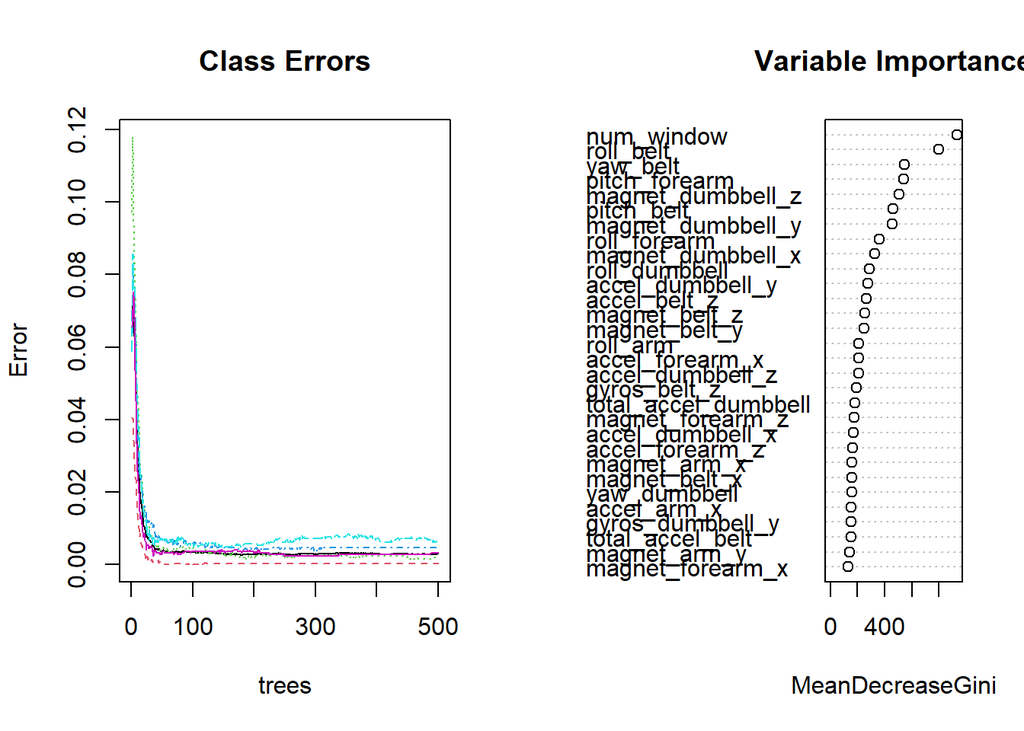

```r
train_rf <- randomForest(factor(classe)~.,data = train_df, proximity=TRUE)

par(mfrow=c(1,2))
plot(train_rf, main = "Class Errors")
varImpPlot(train_rf, main = "Variable Importance")
```

Plotting the importance of each value, the variable num_window clearly has the strongest impact on the accuracy of the model. Nonetheless, no variable listed as an accuracy impact near zero. For this reason, no more variables will be removed.

The error rate demonstrated for each class value also indicates there is no improvement in accuracy for any value at more than 200 trees. We’ll create our initial model using rpart and 5 fold cross validation while also visualizing the decision tree below.

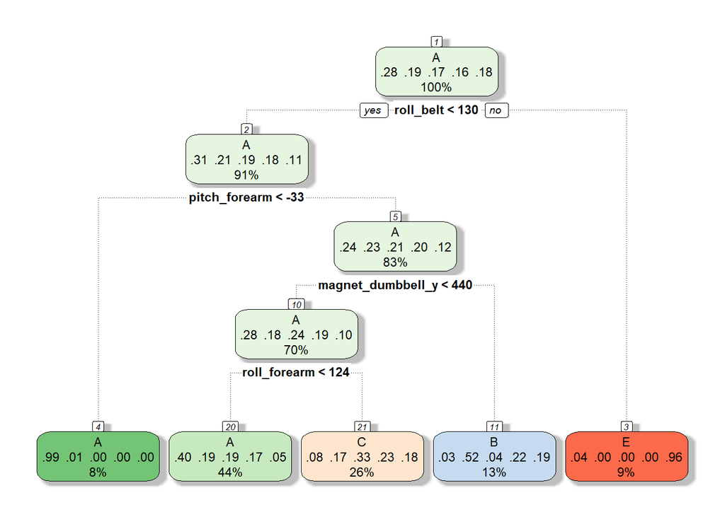

```r
modFit <- train(classe~., method="rpart", data=train_df, trControl=trainControl(method="cv", number=5))

fancyRpartPlot(modFit$finalModel, sub="")
```

```r
print(modFit$finalModel)
```

```
## n= 13737
##
## node), split, n, loss, yval, (yprob)
##       * denotes terminal node
##
##  1) root 13737 9831 A (0.28 0.19 0.17 0.16 0.18)
##    2) roll_belt< 129.5 12486 8627 A (0.31 0.21 0.19 0.18 0.11)
##      4) pitch_forearm< -33.35 1116   10 A (0.99 0.009 0 0 0) *
##      5) pitch_forearm>=-33.35 11370 8617 A (0.24 0.23 0.21 0.2 0.12)
##       10) magnet_dumbbell_y< 439.5 9620 6918 A (0.28 0.18 0.24 0.19 0.1)
##         20) roll_forearm< 123.5 5994 3573 A (0.4 0.19 0.19 0.17 0.054) *
##         21) roll_forearm>=123.5 3626 2416 C (0.077 0.17 0.33 0.23 0.18) *
##       11) magnet_dumbbell_y>=439.5 1750  843 B (0.029 0.52 0.041 0.22 0.19) *
##    3) roll_belt>=129.5 1251   47 E (0.038 0 0 0 0.96) *
```

```r
preds <- predict(modFit, newdata = test_df)
confusionMatrix(preds, factor(test_df$classe))
```

```
## Confusion Matrix and Statistics
##
##           Reference
## Prediction    A    B    C    D    E
##          A 1498  467  473  427  166
##          B   30  379   36  177  137
##          C  119  293  517  360  284
##          D    0    0    0    0    0
##          E   27    0    0    0  495
##
## Overall Statistics
##
##                Accuracy : 0.4909
##                  95% CI : (0.4781, 0.5038)
##     No Information Rate : 0.2845
##     P-Value [Acc > NIR] : < 2.2e-16
##
##                   Kappa : 0.3351
##
##  Mcnemar's Test P-Value : NA
##
## Statistics by Class:
##
##                      Class: A Class: B Class: C Class: D Class: E
## Sensitivity            0.8949   0.3327  0.50390   0.0000  0.45749
## Specificity            0.6360   0.9199  0.78267   1.0000  0.99438
## Pos Pred Value         0.4942   0.4993  0.32867      NaN  0.94828
## Neg Pred Value         0.9383   0.8517  0.88196   0.8362  0.89055
## Prevalence             0.2845   0.1935  0.17434   0.1638  0.18386
## Detection Rate         0.2545   0.0644  0.08785   0.0000  0.08411
## Detection Prevalence   0.5150   0.1290  0.26729   0.0000  0.08870
## Balanced Accuracy      0.7654   0.6263  0.64328   0.5000  0.72593
```

The rpart model generated has very limited accuracy (49%) when run on the test data. We’ll use random forest to create our second model again using 5 fold cross validation.

```r
modFit2 <- train(classe~., data=train_df, method="rf", trControl=trainControl(method="cv", number=5))
modFit2
```

```
## Random Forest
##
## 13737 samples
##    53 predictor
##     5 classes: 'A', 'B', 'C', 'D', 'E'
##
## No pre-processing
## Resampling: Cross-Validated (5 fold)
## Summary of sample sizes: 10991, 10988, 10990, 10990, 10989
## Resampling results across tuning parameters:
##
##   mtry  Accuracy   Kappa
##    2    0.9936670  0.9919889
##   27    0.9964334  0.9954884
##   53    0.9943948  0.9929094
##
## Accuracy was used to select the optimal model using the largest value.
## The final value used for the model was mtry = 27.
```

We now have a model with greater than 99% accuracy. We’ll now test the effectiveness of the model by running it on our test set.

```r
preds2 <- predict(modFit2, newdata = test_df)
confusionMatrix(preds2, factor(test_df$classe))
```

```
## Confusion Matrix and Statistics
##
##           Reference
## Prediction    A    B    C    D    E
##          A 1674    3    0    0    0
##          B    0 1134    3    0    2
##          C    0    2 1023    3    0
##          D    0    0    0  961   10
##          E    0    0    0    0 1070
##
## Overall Statistics
##
##                Accuracy : 0.9961
##                  95% CI : (0.9941, 0.9975)
##     No Information Rate : 0.2845
##     P-Value [Acc > NIR] : < 2.2e-16
##
##                   Kappa : 0.9951
##
##  Mcnemar's Test P-Value : NA
##
## Statistics by Class:
##
##                      Class: A Class: B Class: C Class: D Class: E
## Sensitivity            1.0000   0.9956   0.9971   0.9969   0.9889
## Specificity            0.9993   0.9989   0.9990   0.9980   1.0000
## Pos Pred Value         0.9982   0.9956   0.9951   0.9897   1.0000
## Neg Pred Value         1.0000   0.9989   0.9994   0.9994   0.9975
## Prevalence             0.2845   0.1935   0.1743   0.1638   0.1839
## Detection Rate         0.2845   0.1927   0.1738   0.1633   0.1818
## Detection Prevalence   0.2850   0.1935   0.1747   0.1650   0.1818
## Balanced Accuracy      0.9996   0.9973   0.9980   0.9974   0.9945
```

The accuracy of the predictions are exceptional. The positive and negative prediction rate for the test data is almost 99% accurate across all class types with an out-of-sample error of just ~0.4% for all of the predictions.

## Testing Quiz

Our final model will now use the test set included for the final quiz.

```r
preds3 <- predict(modFit2, newdata=dataset_test)
preds3
```

```
##  [1] B A B A A E D B A A B C B A E E A B B B
## Levels: A B C D E
```

Our model answers the 20 quiz questions with 100% accuracy.

## Bibliography

**Wearable Computing: Accelerometers’ Data Classification of Body Postures and Movements** Ugulino, W.; Cardador, D.; Vega, K.; Velloso, E.; Milidiu, R.; Fuks, H. Wearable Computing: Accelerometers’ Data Classification of Body Postures and Movements. Proceedings of 21st Brazilian Symposium on Artificial Intelligence. Advances in Artificial Intelligence - SBIA 2012. In: Lecture Notes in Computer Science. , pp. 52-61. Curitiba, PR: Springer Berlin / Heidelberg, 2012. ISBN 978-3-642-34458-9. DOI: 10.1007/978-3-642-34459-6_6. Cited by 85 (Google Scholar)

**Read more:** http://groupware.les.inf.puc-rio.br/work.jsf?p1=10335#ixzz6kDAovb7F